# An Example of Imputation

Laha Ale, Robert Gentleman

Updated on : Thu Apr 27 11:51:14 2023

```r
library(splines)
library(ggplot2)
library(ggpubr)
library(phonto)
library(EnWAS)
library(knitr)
library(mice)
library(naniar)
library(visdat)
library(corrplot)
library(DT)
```

### Load data

#### search the targeted variable (LBDLDL)

The questionnaires from 1999 to 2004 are named different from the rest of the years, but the variable LBDLDL represents LDL-cholesterol (mg/dL) across all the years, which can be verified on the nhanes documents on there website; therefore, we can merge the data together.

```r
nhanesSearchVarName('LBDLDL') |> DT::datatable()
```

|  | Variable | Questionnaire | TableName | years |
| --- | --- | --- | --- | --- |
| 1 | LBDLDL | L13AM_B | L13AM | 2001-2002 |
| 2 | LBDLDL | L13AM_C | L13AM | 2003-2004 |
| 3 | LBDLDL | LAB13AM | LAB13AM | 1999-2000 |
| 4 | LBDLDL | TRIGLY_D | TRIGLY | 2005-2006 |
| 5 | LBDLDL | TRIGLY_E | TRIGLY | 2007-2008 |
| 6 | LBDLDL | TRIGLY_F | TRIGLY | 2009-2010 |
| 7 | LBDLDL | TRIGLY_G | TRIGLY | 2011-2012 |
| 8 | LBDLDL | TRIGLY_H | TRIGLY | 2013-2014 |
| 9 | LBDLDL | TRIGLY_I | TRIGLY | 2015-2016 |
| 10 | LBDLDL | TRIGLY_J | TRIGLY | 2017-2018 |

#### merge and PHESANT-like process

```r
cholesterol_tables = nhanesSearchVarName('LBDLDL')$Questionnaire
dlblbl_df = unionQuery(cholesterol_tables,cols =c("LBXTR","LBDLDL","LBDTRSI","LBDLDLSI"))
demo_tables = nhanesSearchTableNames('DEMO')
demo_df = unionQuery(demo_tables,cols =c("RIDAGEYR","RIAGENDR","RIDRETH1","DMDEDUC2","years"))
demo_df = na.omit(demo_df)
data = merge(demo_df,dlblbl_df,by="SEQN")
BMItabs = nhanesSearchVarName('BMXBMI')$Questionnaire
tdf = unionQuery(BMItabs, cols=c("BMXBMI","BMXWT"))

data = merge(data, tdf, by="SEQN")
phs_dat = phesant(data)
data = phs_dat$data

##get whether or not they are using cholesterol lowering drugs
BPQtabs = nhanesSearchVarName("BPQ100D")$Questionnaire
tBPQ = unionQuery(BPQtabs, cols = c('BPQ080','BPQ060', 'BPQ090D','BPQ100D','Questionnaire'))
cholMeds = tBPQ$BPQ100D
cholMeds[tBPQ$BPQ080==2] = 2
cholMeds[tBPQ$BPQ060==2] = 2
cholMeds[tBPQ$BPQ090D==2] = 2
cholMeds = factor(cholMeds,levels=c("1","2"), labels=c("Yes","No"))
table(cholMeds,useNA="always")
```

```
#> cholMeds
#>   Yes    No  <NA>
#> 16765 89684 14691
```

```r
tBPQ$cholMeds = cholMeds
tBPQ = tBPQ[,c("SEQN", "cholMeds")]
data = merge(data, tBPQ, by="SEQN")

DT::datatable(phs_dat$phs_res)
```

|  | r_unique | r_zero | r_NAs | types |
| --- | --- | --- | --- | --- |
| SEQN | 0.267291 | 0 | 0 | Respondent sequence number |
| RIDAGEYR | 0.000695 | 0 | 0 | Continuous |
| RIAGENDR | 2.1e-05 | 0 | 0 | Multilevel(2) |
| RIDRETH1 | 5.3e-05 | 0 | 0 | Multilevel(5) |
| DMDEDUC2 | 7.4e-05 | 0 | 0 | Multilevel(7) |
| years | 0.000105 | 0 | 0 | Multilevel(10) |
| LBXTR | 0.007239 | 0 | 0.06691 | Continuous |
| LBDLDL | 0.002803 | 0 | 0.095254 | Continuous |
| LBDTRSI | 0.011022 | 0 | 0.06691 | Continuous |
| LBDLDLSI | 0.004721 | 0 | 0.095254 | Continuous |

[output cut: 2 more lines]

preprocessing the above data by remove exceptional values and translate gender and enthnicity variables.

```r
data = data[!data$LBDLDL==629,] # remove an exceptional value LBDLDL(9 ~ 375)
data = phonto::nhanesTranslate('DEMO_I', c('RIAGENDR', 'RIDRETH1', 'DMDEDUC2'), data=data) # convert gender and ethnicity to factors
levsED = levels(data$DMDEDUC2)
##examine them and then put into groupings <HS, HS and > HS
levels(data$DMDEDUC2) <- c(">HS","HS",">HS","<HS","<HS","DK","R")
levels(data$DMDEDUC2) <- c(">HS", "HS", "<HS",NA, NA)
```

#### Choose the covariates

Cykert et al [1] used `gender, race, age, hypertension, diabetes, smoking, and systolic blood pressure` to impute HDL and total cholesterol, and Gao et al [2] `race, education, and health insurance type` with adjusted variables, `gender and age`.

In our data the hypertension variable is missing and we want to impute it. For that we probably want to consider good models for hypertension. Somehow it seems odd that BMI was not in their model, and we will include it as it will likely be an important predictor for both hypertension and cholesterol. What was the age range for the paper? We may want to do 40+, just because that is where high cholesterol and hypertension become more prevalent.

[1] Cykert S, DeWalt DA, Weiner BJ, Pignone M, Fine J, Kim JI. A population approach using cholesterol imputation to identify adults with high cardiovascular risk: a report from AHRQ’s EvidenceNow initiative. J Am Med Inform Assoc. 2019 Feb 1;26(2):155-158. doi: 10.1093/jamia/ocy151. PMID: 30496426; PMCID: PMC6373981.

[2] Gao Y, Shah LM, Ding J, Martin SS. US Trends in Cholesterol Screening, Lipid Levels, and Lipid-Lowering Medication Use in US Adults, 1999 to 2018. J Am Heart Assoc. 2023 Feb 7;12(3):e028205. doi: 10.1161/JAHA.122.028205. Epub 2023 Jan 10. PMID: 36625302; PMCID: PMC9973640.

#### diabetes data

```r
diab_tables = nhanesSearchVarName("DIQ010")$Questionnaire
dia_df = unionQuery(diab_tables,cols = c("DIQ010", "DIQ160","DIQ070"))

## fasting glucose
fastgluc = nhanesSearchVarName("LBXGLU")$Questionnaire
gluc_df = unionQuery(fastgluc, cols="LBXGLU")
dia_df = merge(dia_df,gluc_df,by="SEQN")
# Glycohemoglobin
gly_tables = nhanesSearchVarName("LBXGH")$Questionnaire
gly_df = unionQuery(gly_tables, cols="LBXGH")
dia_df = merge(dia_df,gly_df,by="SEQN")

##on meds -
dontskip = dia_df$DIQ010 == 1 | dia_df$DIQ010 == 3 | dia_df$DIQ160 == 1
hypoglycemicMeds = dia_df$DIQ070
hypoglycemicMeds[!dontskip] = 2 #No
hypoglycemicMeds = factor(hypoglycemicMeds,levels=c(1,2,7,9), labels=c("Yes", "No",NA,NA))
table(hypoglycemicMeds,useNA="always")
```

```
#> hypoglycemicMeds
#>   Yes    No  <NA>
#>  3763 41674 17960
```

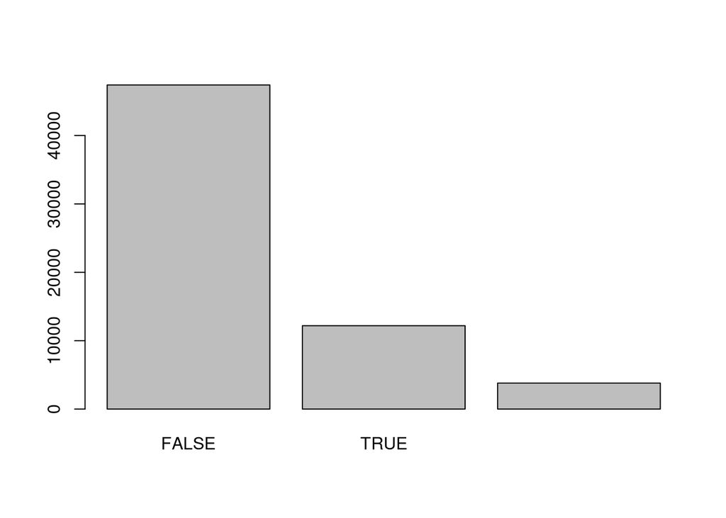

```r
dia_df$hypoglycemicMeds = hypoglycemicMeds

dia_df$diabetes = dia_df$DIQ010 == "Yes" | dia_df$LBXGLU > 110 | dia_df$LBXGH > 6.5
barplot(table(dia_df$diabetes, useNA="always"))
```

#### Hypertension data

```r
# "Hypertension was defined as systolic blood pressure (SBP) ≥140 mm Hg, diastolic blood pressure ≥90mm Hg, or the use of antihypertensive medication. "
bpq_tables = nhanesSearchVarName('BPQ050A')$Questionnaire
bpq_df = unionQuery(bpq_tables,cols = c('BPQ050A','BPQ020','BPQ040A', 'BPQ060','BPQ080','BPQ100D'))

hypertensiveMeds = bpq_df$BPQ050A
hypertensiveMeds[bpq_df$BPQ020==2] = 2
hypertensiveMeds[bpq_df$BPQ040A==2] = 2
##need to fix up the hypertension variable or we get lots of missing values
#set up a dummy for the ones we want to change - also turn "Don't know" from BPQ020 into NA
#  gg = is.na(bpq_df$BPQ050A) & bpq_df$BPQ020==2
#  bpq50A = bpq_df$BPQ050A
#  bpq50A[gg] = 2
 #check it worked
 # table(bpq50A, bpq_df$BPQ050A, useNA="always")
table(hypertensiveMeds, useNA="always")
```

```
#> hypertensiveMeds
#>     1     2     9  <NA>
#> 27811 92634    10   685
```

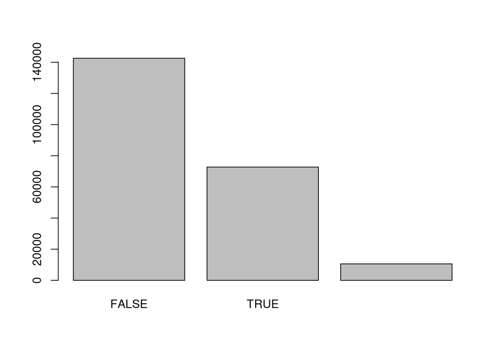

```r
bpq_df$hypertensiveMeds = hypertensiveMeds

bpx_tables = nhanesSearchVarName('BPXSY1')$Questionnaire
bpx_df = unionQuery(bpx_tables,cols = c("BPXSY1","BPXSY2","BPXDI1","BPXDI2"))
bpx_df$DIASTOLIC <- rowMeans(bpx_df[, c("BPXDI1", "BPXDI2")], na.rm=TRUE)
bpx_df$DIASTOLIC[is.na(bpx_df$BPXDI1) & is.na(bpx_df$BPXDI2)] = NA
bpx_df$SYSTOLIC <- rowMeans(bpx_df[, c("BPXSY1", "BPXSY2")], na.rm=TRUE)
bpx_df$SYSTOLIC[is.na(bpx_df$BPXSY1) & is.na(bpx_df$BPXSY2)] = NA


bpx_df = merge(bpx_df,bpq_df,by="SEQN")

bpx_df$hypertension <- bpx_df$DIASTOLIC >= 90 | bpx_df$SYSTOLIC >= 140 |  bpx_df$hypertensiveMeds==1
barplot(table(bpx_df$hypertension, useNA="always"))
```

#### smoking data

```r
smoke_tables = nhanesSearchVarName('SMQ020')$Questionnaire
smoke_df = unionQuery(smoke_tables,cols = c("SMQ020","SMQ040"))

nhanesTranslate("SMQ_J", colnames=c("SMQ020","SMQ040"))
```

```
#> $SMQ020
#>   Variable CodeOrValue ValueDescription
#> 1   SMQ020           1              Yes
#> 2   SMQ020           2               No
#> 3   SMQ020           7          Refused
#> 4   SMQ020           9       Don't know
#> 5   SMQ020           .          Missing
#>
#> $SMQ040
#>    Variable CodeOrValue ValueDescription
#> 6    SMQ040           1        Every day
#> 7    SMQ040           2        Some days
#> 8    SMQ040           3       Not at all
#> 9    SMQ040           7          Refused
#> 10   SMQ040           9       Don't know
#> 11   SMQ040           .          Missing
```

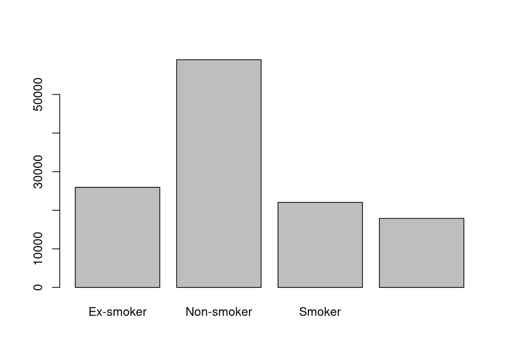

```r
smokingVar = ifelse(smoke_df$SMQ020==2, "Non-smoker", ifelse(smoke_df$SMQ040==3, "Ex-smoker",
                    "Smoker"))
smoke_df$smoking = smokingVar
barplot(table(smokingVar, useNA="always"))
```

#### merge data and show the missingness

We merged the demographic data with information on diabetes, hypertension, and smoking data. Additionally, we demonstrate the missingness of the data by columns.

```r
data = merge(data,dia_df[,c('SEQN','diabetes')], by="SEQN")
data = merge(data,bpx_df[,c('SEQN','hypertension','SYSTOLIC')], by="SEQN")
data = merge(data,smoke_df[,c('SEQN','smoking')], by="SEQN")
sapply(data, function(x) sum(is.na(x)))
```

```
#>         SEQN     RIDAGEYR     RIAGENDR     RIDRETH1     DMDEDUC2        years
#>            0            0            0            0         3204            0
#>        LBXTR       LBDLDL      LBDTRSI     LBDLDLSI       BMXBMI        BMXWT
#>            0            0            0            0        42761        34184
#>     cholMeds     diabetes hypertension     SYSTOLIC      smoking
#>        61110         6785        99513       129717         2307
```

The plot below illustrates the missingness pattern, indicating that the hypertension column has a considerable number of missing values, with a higher proportion of missing values among the younger age population.

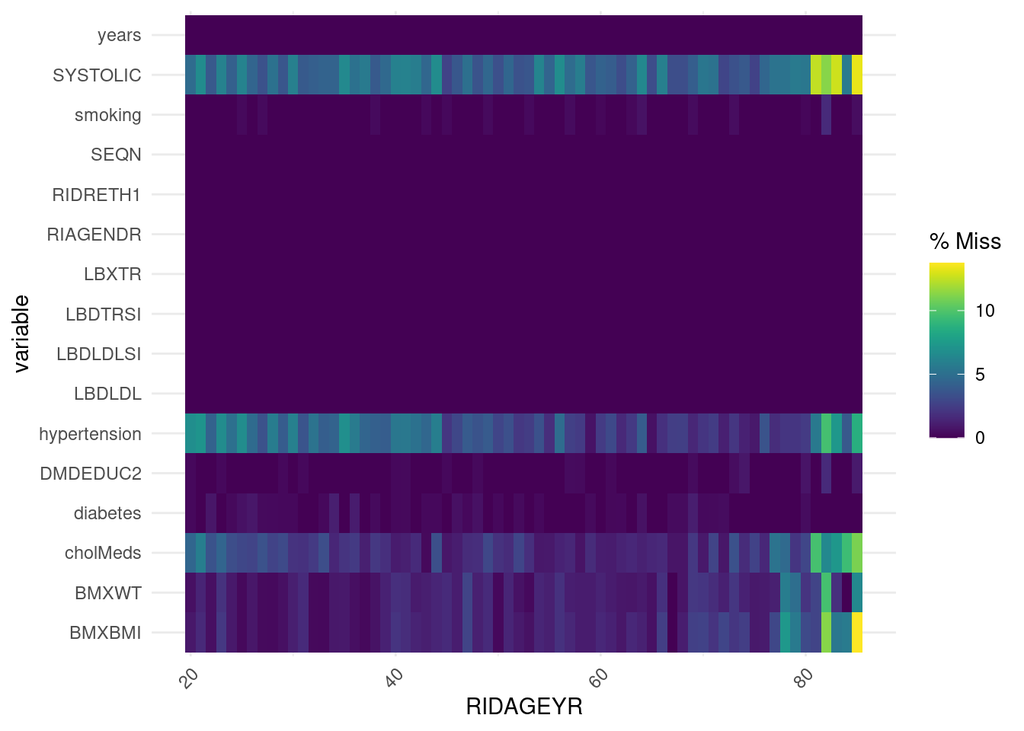

```r
gg_miss_fct(data,fct = RIDAGEYR)
```

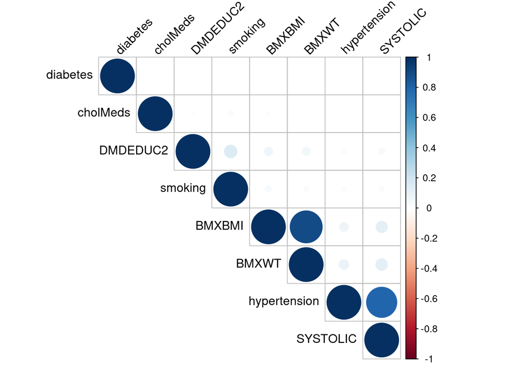

```r
missing_cols = sapply(data, function(x)sum(is.na(x)))
missing_cols = missing_cols[missing_cols>0] # select the data with missing values

correlation = cor(is.na(data[,names(missing_cols)]))
corrplot(correlation, type = "upper", order = "hclust",
         tl.col = "black", tl.srt = 45)
```

### split traning and testing data

At this point, we have excluded hypertension from our analysis due to the excessive amount of missing values it contains. Additionally, to validate the regression or imputation models, we have eliminated the records that contain missing values.

```r
data = data[,c("SEQN","RIDAGEYR","RIAGENDR" , "RIDRETH1" , "DMDEDUC2" ,"LBDLDL" ,"diabetes" ,"SYSTOLIC" ,"smoking","BMXBMI","BMXWT", "cholMeds")]
data_clean = na.omit(data)
data_clean = data_clean[data_clean$RIDAGEYR>49,]
# data = data[data$RIDAGEYR>40,] # remove age below 40
# split training and testing data set
test_ix = sample(x = 1:nrow(data_clean), size = 15000) # about 10%
train_ix = sample(x = setdiff(1:nrow(data_clean), test_ix), size=110000)

train_data = data_clean[train_ix, ]
test_data = data_clean[test_ix, ]

MSE <- function(y_true, y_pred){
    mean((y_true - y_pred)^2)
}
```

## Imputation

To apply EnWAS methods for uncovering new covariates, it is necessary to confirm that the covariates introduced in the previous papers are suitable for predicting or imputing the target values. However, the imputation results were not satisfactory, as evaluated by mean square error. We also present a scatter plot to visualize the predicted values in relation to the true values.

## chatGPT-4

```r
mod = lm(formula = LBDLDL ~ ns(RIDAGEYR, df=7) + cholMeds + RIAGENDR, data=data_clean)
mod = lm(formula = LBDLDL ~ ns(BMXBMI, df=7) + cholMeds + RIAGENDR, data=data_clean)
mod = lm(formula = LBDLDL ~ DMDEDUC2 + cholMeds, data=data_clean)
mod = lm(formula = LBDLDL ~ ns(BMXWT, df=7) + cholMeds, data=data_clean)
mod = lm(formula = LBDLDL ~ smoking, data=data_clean)
```

#### Diet

Let’s try to add diet as ChatGPT suggestion

```r
# saturated fat
# fat_tb = nhanesSearchVarName("DR1TSFAT")$Questionnaire
# fat_df = unionQuery(fat_tb, cols="DR1TSFAT")
# data = merge(data,fat_df,by="SEQN")
# mod = lm(formula = LBDLDL ~ ns(BMXWT, df=7) + cholMeds+smoking, data=data[data$RIDAGEYR>50,])
# summary(mod)
```

#### regression model

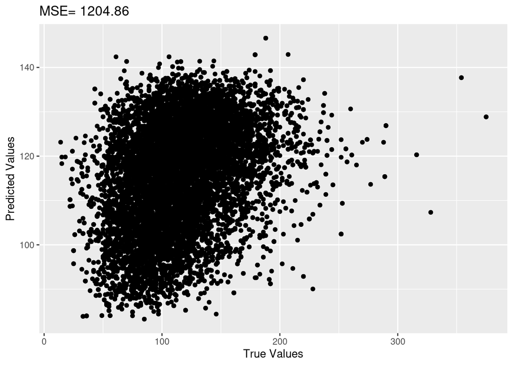

```r
lm_reg = lm(formula = LBDLDL ~ ns(RIDAGEYR, df=7) + cholMeds +RIAGENDR + RIDRETH1+DMDEDUC2+smoking+SYSTOLIC, data = train_data)

pred_data = predict(lm_reg, newdata = test_data)
mse = MSE(test_data$LBDLDL,pred_data)
qplot(test_data$LBDLDL,pred_data) +labs(title=paste("MSE=",round(mse,2)),
        x ="True Values", y = "Predicted Values")
```

#### nnet model

```r
library(nnet)
nn <- nnet(LBDLDL ~ RIDAGEYR+ cholMeds +RIAGENDR + RIDRETH1+DMDEDUC2+smoking+SYSTOLIC,
                data = train_data, size=3,hidden = c(8, 8,4),
                linear.output = TRUE)
```

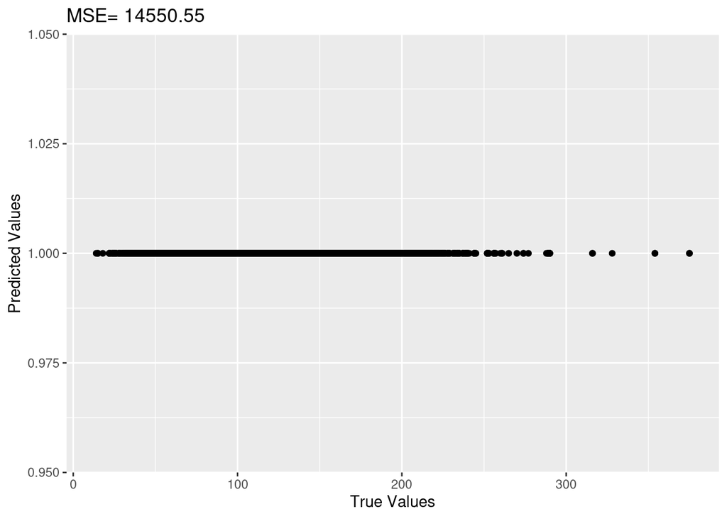

```r
pred_data = predict(nn, newdata = test_data)
mse = MSE(test_data$LBDLDL,pred_data)
qplot(test_data$LBDLDL,pred_data) +labs(title=paste("MSE=",round(mse,2)),
        x ="True Values", y = "Predicted Values")
```

#### MICE

```r
# train_data = head(train_data,3000)
# train_data[test_ix[1:3000],"LBDLDL"]=NA
# train_data$SEQN=NULL
#
# imp <-  mice(train_data, print=F)
# meth <- imp$meth
# meth[c("RIDAGEYR","RIAGENDR" ,"cholMeds", "RIDRETH1" , "DMDEDUC2" ,"LBDLDL" ,"diabetes" ,"SYSTOLIC" ,"smoking")]="cart"
# imp <- mice(train_data, m=1, method = meth, print=F)
# imp20  <-  mice.mids(imp, maxit=10, print=F)
#
# complete_data <- mice::complete(imp20,action=1)
# qplot(test_data$LBDLDL,complete_data[test_ix[1:3000],"LBDLDL"]) +labs(title=paste("MSE=",round(mse,2)),
#         x ="True Values", y = "Predicted Values")
```